# Pre-filter

2023-03-13

#### **Introduction**

Large and heterogeneous datasets may contain thousands of records missing spatial or taxonomic information (partially or entirely) as well as several records outside a region of interest or from doubtful sources. Such lower quality data are not fit for use in many research applications without prior amendments. The ‘Pre-filter’ module contains a series of **tests to detect, remove, and, whenever, possible, correct such erroneous or suspect records**.

#### **Installation**

Check [**here**](https://brunobrr.github.io/bdc/#installation) how to install the bdc package.

#### **Reading the database**

Read the merged database created in the module **Standardization and integration of different datasets** of the *bdc* package. It is also possible to read any datasets containing the **required** fields to run the functions (more details [here](https://brunobrr.github.io/bdc/articles/integrate_datasets.html)).

```r
database <-
  readr::read_csv(here::here("Output/Intermediate/00_merged_database.csv"))
```

| database_id | scientificName | decimalLatitude | decimalLongitude | occurrenceID | verbatimEventDate | country | stateProvince | county | locality | coordinatePrecision | basisOfRecord | identifiedBy | coordinateUncertaintyInMeters | recordedBy |
| --- | --- | --- | --- | --- | --- | --- | --- | --- | --- | --- | --- | --- | --- | --- |
| AT_EPIPHYTES_1 | Tillandsia tenuifolia | -25.521863 | -51.416667 | E8802 | 2003 | Brazil | PARANA | GUARAPUAVA | Rio Sao Jeronimo | Forest fragment |  |  |  |  |
| AT_EPIPHYTES_2 | Peperomia obtusifolia | -14.65972 | -39.14972 | 635992 | 2015 | Brazil | BAHIA | ILHEUS |  | Coordinates given in the herbarium record |  |  |  |  |
| AT_EPIPHYTES_3 | Tillandsia recurvata | -21.746667 | -43.354722 | E1617 | 2016 | Brazil | MATO GROSSO DO SUL | JUIZ DE FORA | Praca Mariano Procopio | 50 |  |  |  |  |
| AT_EPIPHYTES_4 | Vriesea flammea | -23.35 | -44.858333 | E0272 | 2011 | Brazil | SAO PAULO | UBATUBA | Parque Estadual da Serra do Mar-Nucleo Picinguaba | Forest fragment |  |  |  |  |
| AT_EPIPHYTES_5 | Lankesterella ceracifolia | -28.1667 | -49.4 | 17541 | 2009 | Brazil | SANTA CATARINA | ORLEANS | Rio Minador | Municipality |  |  |  |  |
| AT_EPIPHYTES_6 | Vriesea psittacina | -15.133333 | -38.333333 | E32704 |  | Brazil | BAHIA | UNA | Serra Javi. 9Km ao S Sao Jose -Km 550-; 5.5Km a E BR-101, p/ Faz. Cascavel. | Coordinates given in the herbarium record |  |  |  |  |
| AT_EPIPHYTES_7 | Nidularium innocentii | -26.1833 | -49.0333 | 20521 | 2009 | Brazil | SANTA CATARINA | JOINVILLE | Serra Dona Francisca | Municipality |  |  |  |  |
| AT_EPIPHYTES_8 | Acianthera serpentula | -25.5839 | -49.6356 | E23503 |  | Brazil | PARANA | BALSA NOVA | Base da Serra de Sao Luiz do Puruna | Coordinates given in the herbarium record |  |  |  |  |
| AT_EPIPHYTES_9 | Peperomia quadrifolia | -26.46 | -49.41 | E18657 |  | Brazil | SANTA CATARINA | CORUPA | Palmeiras II | Coordinates given in the herbarium record |  |  |  |  |
| AT_EPIPHYTES_10 | Peperomia circinnata | -23.7869 | -54.2836 | E16998 |  | Brazil | MATO GROSSO DO SUL | ELDORADO |  | Coordinates given in the herbarium record |  |  |  |  |

[output cut: 5 more lines]

⚠️**IMPORTANT:**

The results of the **VALIDATION** test used to flag data quality are appended in separate fields in this database and retrieved as TRUE ( ✅ ok ) or **FALSE** (❌check carefully ).

#### **1 - Records missing species names**

*VALIDATION*. Flag records missing species names.

```r
check_pf <-
  bdc_scientificName_empty(
  data = database,
  sci_name = "scientificName")
```

```
#> bdc_scientificName_empty:
#> Flagged 5 records.
#> One column was added to the database.
```

#### **2 - Records lacking information on geographic coordinates**

*VALIDATION*. Flag records missing partial or complete information on geographic coordinates.

```r
check_pf <- bdc_coordinates_empty(
  data = check_pf,
  lat = "decimalLatitude",
  lon = "decimalLongitude")
```

```
#> bdc_coordinates_empty:
#> Flagged 44 records.
#> One column was added to the database.
```

#### **3 - Records with out-of-range coordinates**

*VALIDATION*. This test flags records with out-of-range coordinates: latitude > 90 or -90; longitude >180 or -180.

```r
check_pf <- bdc_coordinates_outOfRange(
  data = check_pf,
  lat = "decimalLatitude",
  lon = "decimalLongitude")
```

```
#> bdc_coordinates_outOfRange:
#> Flagged 1 records.
#> One column was added to the database.
```

#### **4 - Records from doubtful sources**

*VALIDATION*. This test flags records from doubtful source. For example, records from drawings, photographs, or multimedia objects, fossil records, among others.

```r
# Check record sources of your dataset using:
# check_pf %>%
#   dplyr::group_by(basisOfRecord) %>%
#   dplyr::summarise(n = dplyr::n())

check_pf <- bdc_basisOfRecords_notStandard(
  data = check_pf,
  basisOfRecord = "basisOfRecord",
  names_to_keep = "all")
```

```
#> bdc_basisOfRecords_notStandard:
#> Flagged 0 of the following specific nature:
#>  character(0)
#> One column was added to the database.
```

#### **5 - Getting country names from valid coordinates**

*ENRICHMENT*. Deriving country names for records missing country names.

```r
check_pf <- bdc_country_from_coordinates(
  data = check_pf,
  lat = "decimalLatitude",
  lon = "decimalLongitude",
  country = "country")
```

```
#> bdc_country_from_coordinates:
#> Country names were added to 27 records.
```

#### **6 - Standardizing country names and getting country code information**

*ENRICHMENT*. Country names are standardized against a list of country names in several languages retrieved from Wikipedia.

```r
check_pf <- bdc_country_standardized(
  data = check_pf,
  country = "country"
)
```

```
#> Standardizing country names
#>
#> country found: Bolivia
#> country found: Brazil
#>   |++++++++++++++++++++++++++++++++++++++++++++++++++| 100% elapsed=00s
#>   |++++++++++++++++++++++++++++++++++++++++++++++++++| 100% elapsed=00s
#>   |++++++++++++++++++++++++++++++++++++++++++++++++++| 100% elapsed=00s
#>
#> bdc_country_standardized:
#> The country names of 65 records were standardized.
#> Two columns ('country_suggested' and 'countryCode') were added to the database.
```

#### **7 - Correcting latitude and longitude transposed**

*AMENDMENT*. The mismatch between informed country and coordinates can be the result of negative or transposed coordinates. Once detected a mismatch, different coordinate transformations are made to correct the country and coordinates mismatch. Verbatim coordinates are then replaced by the rectified ones in the returned database (a database containing verbatim and corrected coordinates can be created in the “Output” folder if `save_outputs = TRUE`). Records near countries coastline are not tested to avoid incur in false positives.

```r
check_pf <-
  bdc_coordinates_transposed(
    data = check_pf,
    id = "database_id",
    sci_names = "scientificName",
    lat = "decimalLatitude",
    lon = "decimalLongitude",
    country = "country_suggested",
    countryCode = "countryCode",
    border_buffer = 0.2, # in decimal degrees (~22 km at the equator)
    save_outputs = FALSE
  )
```

```
#> Correcting latitude and longitude transposed
#>
#> 15 occurrences will be tested
#> Processing occurrences from: BR (15)
#> No latitude and longitude were transposed
```

#### **8 - Records outside a region of interest**

*VALIDATION*. Records outside one or multiple reference countries; i.e., records in other countries or at an informed distance from the coast (e.g., in the ocean). This last step avoids flagging as invalid records close to country limits (e.g., records of coast or marshland species).

```r
check_pf <-
  bdc_coordinates_country_inconsistent(
    data = check_pf,
    country_name = "Brazil",
    country = "country_suggested",
    lon = "decimalLongitude",
    lat = "decimalLatitude",
    dist = 0.1 # in decimal degrees (~11 km at the equator)
  )
```

```
#> dist is assumed to be in decimal degrees (arc_degrees).
#> although coordinates are longitude/latitude, st_intersection assumes that they are planar
#>
#> bdc_coordinates_country_inconsistent:
#> Flagged 15 records.
#> One column was added to the database.
```

#### **9 - Identifying records not geo-referenced but containing locality information**

*ENRICHMENT*. Coordinates can be derived from a detailed description of the locality associated with records in a process called retrospective geo-referencing.

```r
xyFromLocality <- bdc_coordinates_from_locality(
  data = check_pf,
  locality = "locality",
  lon = "decimalLongitude",
  lat = "decimalLatitude",
  save_outputs = FALSE
)
```

```
#> bdc_coordinates_from_locality
#> Found 38 records missing or with invalid coordinates but with potentially useful information on locality
```

#### **Report**

Here we create a column named “.summary” summing up the results of all **VALIDATION** tests (those starting with “.”). This column is **FALSE** when a record is flagged as FALSE in any data quality test (i.e. potentially invalid or suspect record).

```r
check_pf <- bdc_summary_col(data = check_pf)
```

```
#> bdc_summary_col:
#> Flagged 65 records.
#> One column was added to the database.
```

Creating a report summarizing the results of all tests. The report can be automatically saved if `save_report = TRUE.`

```r
report <-
  bdc_create_report(data = check_pf,
                    database_id = "database_id",
                    workflow_step = "prefilter",
                    save_report = FALSE)

report
```

| Description | Test_name | Records_flagged | perc_number_records(*) |
| --- | --- | --- | --- |
| Records with empty scientific name | .scientificName_empty | 5 | 2.78 |
| Records with empty coordinates | .coordinates_empty | 44 | 24.44 |
| Records with coordinates out-of-range | .coordinates_outOfRange | 1 | 0.56 |
| Records outside one or multiple reference countries | .coordinates_country_inconsistent | 15 | 8.33 |
| Summary of all tests | .summary | 65 | 36.11 |
| (*) calculated in relation to total number of records, i.e. 180 records |  |  |  |

#### **Figures**

Here we create figures (bar plots and maps) to make the interpretation of the results of data quality tests easier. See some examples below. Figures can be automatically saved if `save_figures = TRUE.`

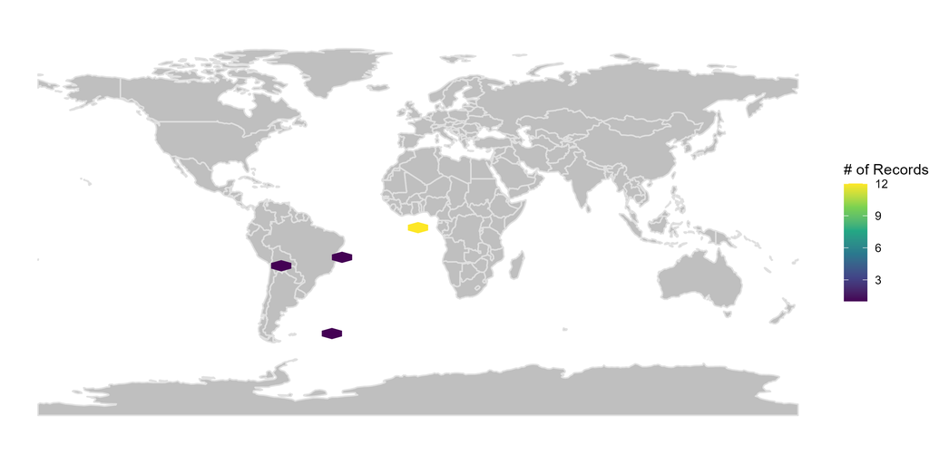

Coordinates country inconsistent

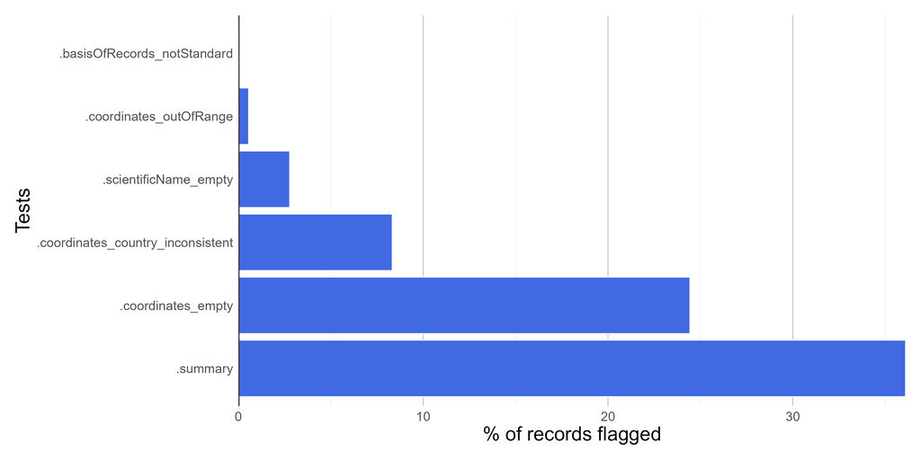

Summary of all tests of the pre-filter step

```r
figures <-
bdc_create_figures(data = check_pf,
                   database_id = "database_id",
                   workflow_step = "prefilter",
                   save_figures = FALSE)

# Check figures using
figures$.coordinates_country_inconsistent
```

#### **Filtering the database**

We can remove records flagged as erroneous or suspect to obtain a “clean” database. Records missing names or coordinates, outside a region of interest or from distrustful sources are rarely suitable for biodiversity analyses. We can use the column **.summary** to filter valid records passing in all tests (i.e., flagged as “TRUE”). Next, we use the *bdc_filter_out_falgs* function to remove all tests’ columns (that is, those starting with “.”).

```r
output <-
  check_pf %>%
  dplyr::filter(.summary == TRUE) %>%
  bdc_filter_out_flags(data = ., col_to_remove = "all")
```

```
#> bdc_fiter_out_flags:
#> The following columns were removed from the database:
#> .scientificName_empty, .coordinates_empty, .coordinates_outOfRange, .basisOfRecords_notStandard, .coordinates_country_inconsistent, .summary
```

#### **Saving the database**

You can use qs::qsave() instead of write_csv to save a large database in a compressed format.

```r
# use qs::qsave() to save the database in a compressed format and then qs:qread() to load the database
output %>%
  readr::write_csv(.,
            here::here("Output", "Intermediate", "01_prefilter_database.csv"))
```